# Cancer Prediction

"Importing The Required Libraries & Packages"

```python
import numpy as np
import pandas as pd
import matplotlib.pyplot as plt
import seaborn as sns
import os
import warnings
warnings.filterwarnings('ignore')
%matplotlib inline
from sklearn.model_selection import train_test_split
from sklearn.model_selection import GridSearchCV,cross_val_score
from sklearn.svm import SVC
from sklearn.metrics import accuracy_score,classification_report,confusion_matrix
from xgboost import XGBClassifier
from sklearn.tree import DecisionTreeClassifier
from sklearn.ensemble import RandomForestClassifier,ExtraTreesClassifier
from sklearn.preprocessing import StandardScaler
```

"Changing The Default Working Directory & Path "

```python
os.chdir('D:\\bala\\study things\\data science\\Batch 74 Day 31\\Batch 74 Day 31\\Project to Explain Classifciation\\')
```

"Reading The Dataset Using Pandas Command"

```python
df = pd.read_csv('data.csv')
```

"Checking the Null values of all the Columns in the dataset"

```python
df.isnull().sum()
```

```
id                         0
diagnosis                  0
radius_mean                0
texture_mean               0
perimeter_mean             0
area_mean                  0
smoothness_mean            0
compactness_mean           0
concavity_mean             0
concave points_mean        0
symmetry_mean              0
fractal_dimension_mean     0
radius_se                  0
texture_se                 0
perimeter_se               0
area_se                    0
smoothness_se              0
compactness_se             0
concavity_se               0
concave points_se          0
symmetry_se                0
fractal_dimension_se       0
radius_worst               0
texture_worst              0
perimeter_worst            0
area_worst                 0
smoothness_worst           0
compactness_worst          0
concavity_worst            0
concave points_worst       0
symmetry_worst             0
fractal_dimension_worst    0
dtype: int64
```

"Checking the data type of all available columns in the dataset"

```python
df.dtypes
```

```
id                           int64
diagnosis                   object
radius_mean                float64
texture_mean               float64
perimeter_mean             float64
area_mean                  float64
smoothness_mean            float64
compactness_mean           float64
concavity_mean             float64
concave points_mean        float64
symmetry_mean              float64
fractal_dimension_mean     float64
radius_se                  float64
texture_se                 float64
perimeter_se               float64
area_se                    float64
smoothness_se              float64
compactness_se             float64
concavity_se               float64
concave points_se          float64
symmetry_se                float64
fractal_dimension_se       float64
radius_worst               float64
texture_worst              float64
perimeter_worst            float64
area_worst                 float64
smoothness_worst           float64
compactness_worst          float64
concavity_worst            float64
concave points_worst       float64
symmetry_worst             float64
fractal_dimension_worst    float64
dtype: object
```

"Checking the dataset whether its is having a duplicate values or not"

```python
df.duplicated().sum()
```

```
0
```

"Label Encoding the diagnosis column in the dataset"

```python
df['diagnosis']=df['diagnosis'].astype('category')
```

```python
df['diagnosis']=df['diagnosis'].cat.codes
```

"Checking the value counts for diagnosis columns "

```python
df['diagnosis'].value_counts()
```

```
0    357
1    212
Name: diagnosis, dtype: int64
```

" Checking the total shape of the dataset "

```python
df.shape
```

```
(569, 32)
```

"Assigning the dependent and independent variables"

```python
x = df.drop(['id','diagnosis'],axis=1)
y = df['diagnosis']
```

"Getting the correlation value from all the numeric columns from the independent variable using seaborn Heatmap & sacing the PNG file "

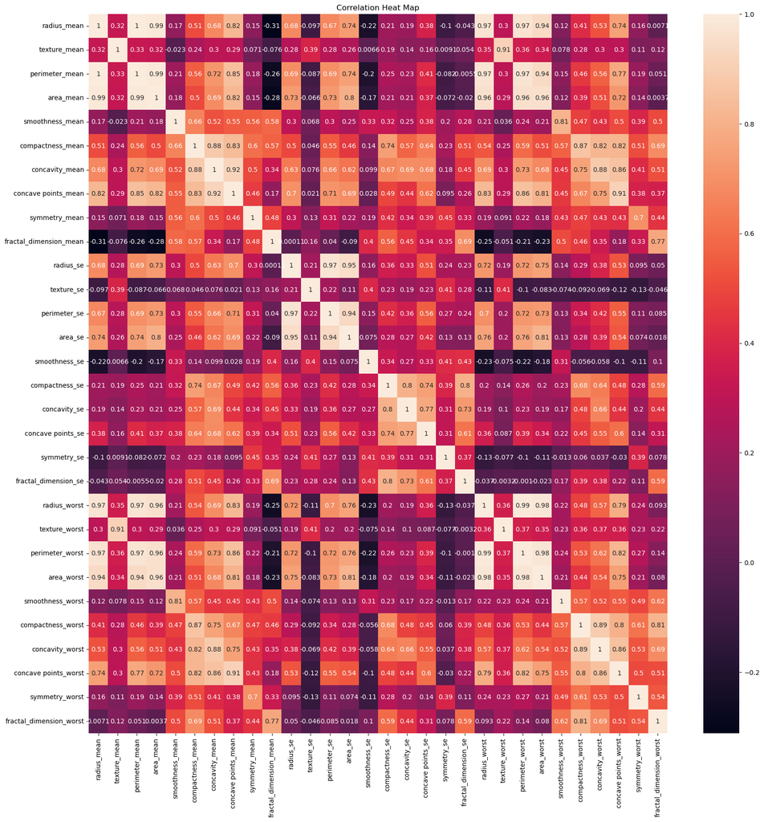

```python
co_rel= x.corr()
plt.rcParams['figure.figsize']=(20,20)
sns.heatmap (co_rel,annot = True)
plt.title('Correlation Heat Map')
plt.savefig('Correlation Heat Map.png')
plt.show()
```

"Checking The outlier of all columns of the independent variables using Seaborn box plot in the following six cells"

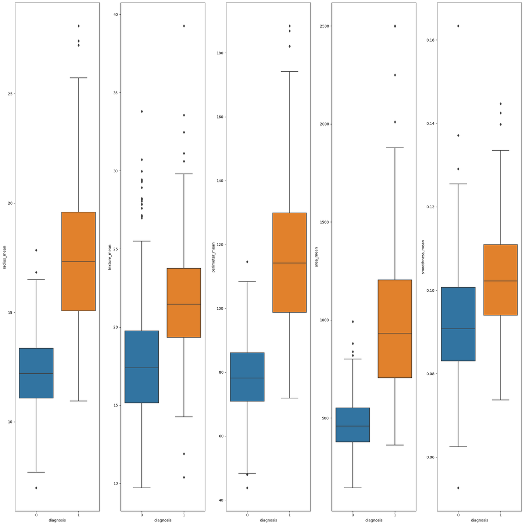

```python
f, (ax1,ax2,ax3,ax4,ax5) = plt.subplots (1,5) # 1 -Number of rows 5 -Number of columns
sns.boxplot ( x= df['diagnosis'], y = df['radius_mean'], ax = ax1)
sns.boxplot (x= df['diagnosis'], y = df['texture_mean'], ax = ax2)
sns.boxplot (x= df['diagnosis'], y = df['perimeter_mean'], ax = ax3)
sns.boxplot (x= df['diagnosis'], y = df['area_mean'] , ax = ax4)
sns.boxplot (x= df['diagnosis'], y = df['smoothness_mean']  , ax = ax5)
f .tight_layout()
```

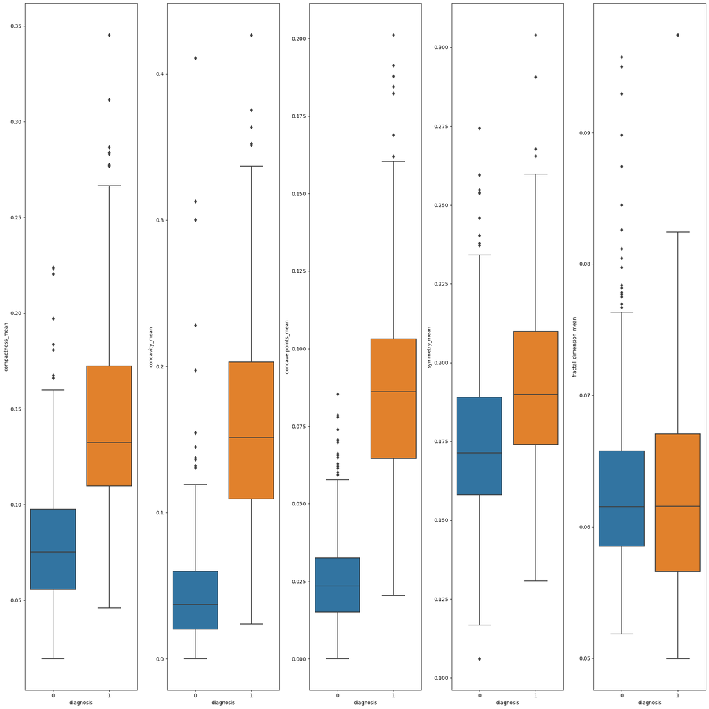

```python
f, (ax1,ax2,ax3,ax4,ax5) = plt.subplots (1,5)
sns.boxplot (x= df['diagnosis'], y = df['compactness_mean'], ax = ax1)
sns.boxplot (x= df['diagnosis'], y = df['concavity_mean'] , ax = ax2)
sns.boxplot (x= df['diagnosis'], y = df['concave points_mean'] , ax = ax3)
sns.boxplot (x= df['diagnosis'], y = df['symmetry_mean'], ax = ax4)
sns.boxplot (x= df['diagnosis'], y = df['fractal_dimension_mean'] , ax = ax5)
f .tight_layout()
```

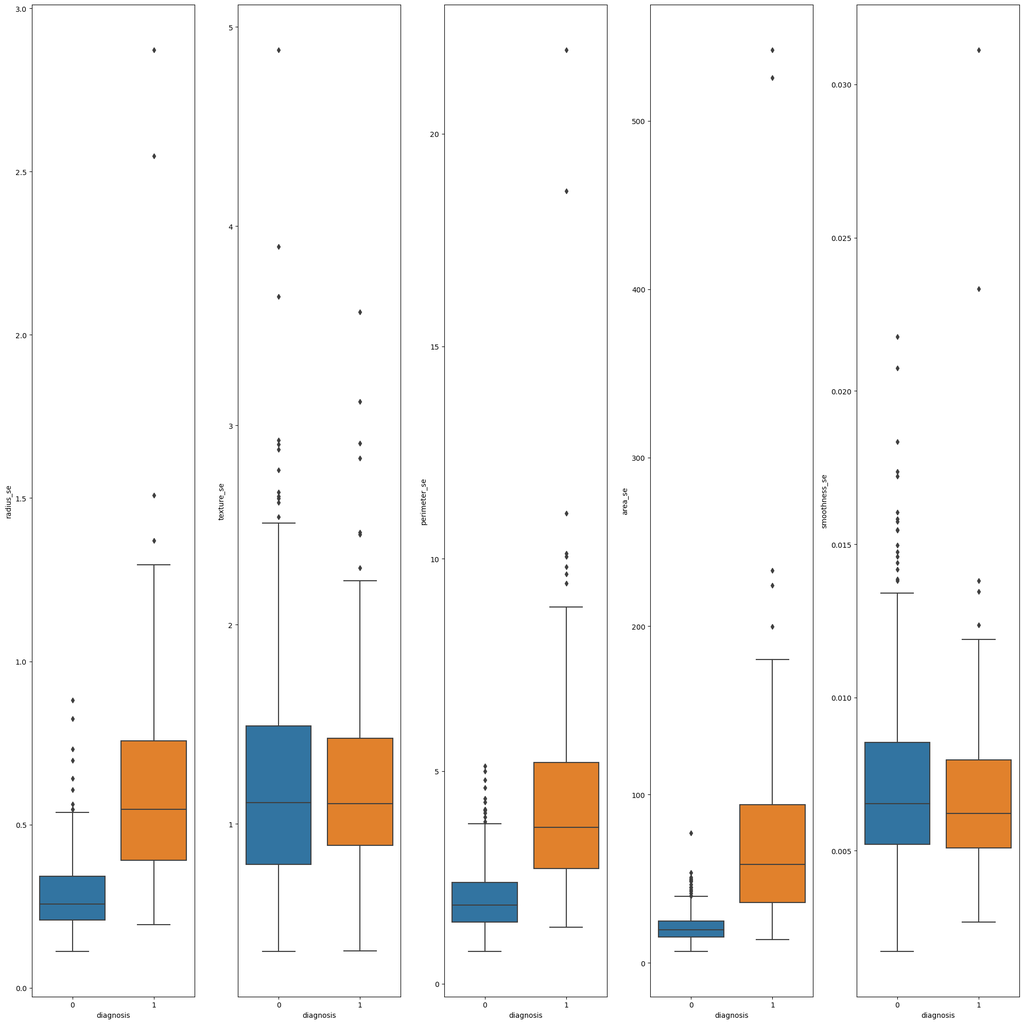

```python
f, (ax1,ax2,ax3,ax4,ax5) = plt.subplots (1,5) # 1 -Number of rows 5 -Number of columns
sns.boxplot ( x= df['diagnosis'], y = df['radius_se'], ax = ax1)
sns.boxplot (x= df['diagnosis'], y = df['texture_se'], ax = ax2)
sns.boxplot (x= df['diagnosis'], y = df['perimeter_se'], ax = ax3)
sns.boxplot (x= df['diagnosis'], y = df['area_se'] , ax = ax4)
sns.boxplot (x= df['diagnosis'], y = df['smoothness_se']  , ax = ax5)
f .tight_layout()
```

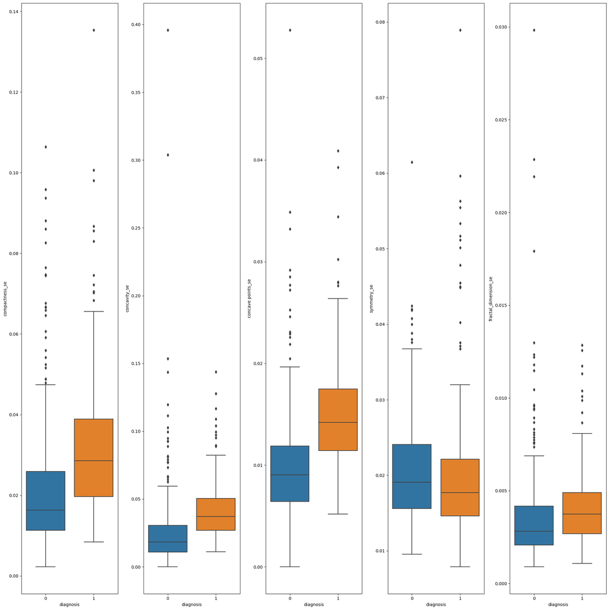

```python
f, (ax1,ax2,ax3,ax4,ax5) = plt.subplots (1,5)
sns.boxplot (x= df['diagnosis'], y = df['compactness_se'], ax = ax1)
sns.boxplot (x= df['diagnosis'], y = df['concavity_se'] , ax = ax2)
sns.boxplot (x= df['diagnosis'], y = df['concave points_se'] , ax = ax3)
sns.boxplot (x= df['diagnosis'], y = df['symmetry_se'], ax = ax4)
sns.boxplot (x= df['diagnosis'], y = df['fractal_dimension_se'] , ax = ax5)
f .tight_layout()
```

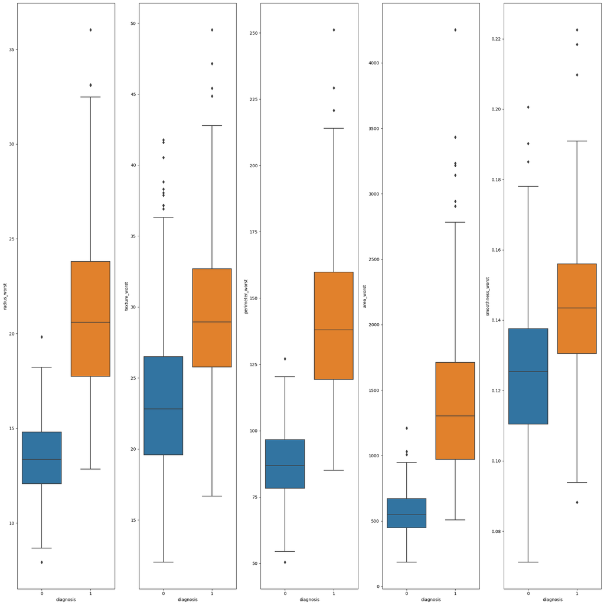

```python
f, (ax1,ax2,ax3,ax4,ax5) = plt.subplots (1,5) # 1 -Number of rows 5 -Number of columns
sns.boxplot ( x= df['diagnosis'], y = df['radius_worst'], ax = ax1)
sns.boxplot (x= df['diagnosis'], y = df['texture_worst'], ax = ax2)
sns.boxplot (x= df['diagnosis'], y = df['perimeter_worst'], ax = ax3)
sns.boxplot (x= df['diagnosis'], y = df['area_worst'] , ax = ax4)
sns.boxplot (x= df['diagnosis'], y = df['smoothness_worst']  , ax = ax5)
f .tight_layout()
```

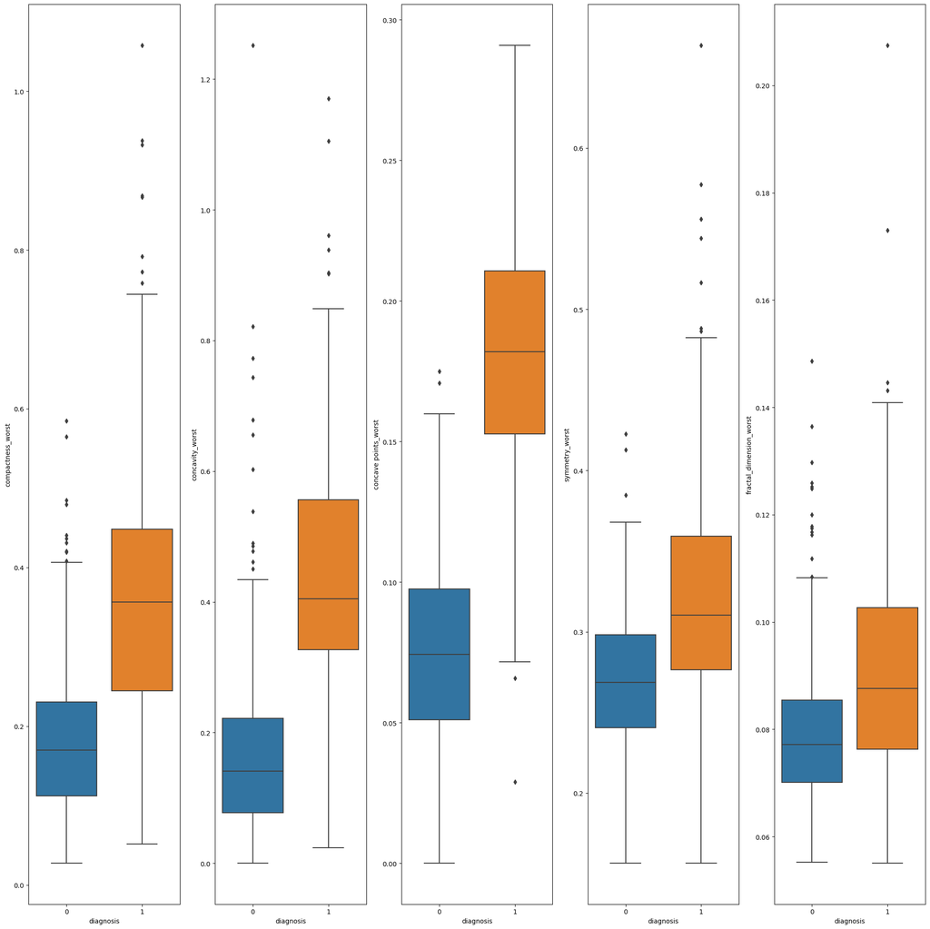

```python
f, (ax1,ax2,ax3,ax4,ax5) = plt.subplots (1,5)
sns.boxplot (x= df['diagnosis'], y = df['compactness_worst'], ax = ax1)
sns.boxplot (x= df['diagnosis'], y = df['concavity_worst'] , ax = ax2)
sns.boxplot (x= df['diagnosis'], y = df['concave points_worst'] , ax = ax3)
sns.boxplot (x= df['diagnosis'], y = df['symmetry_worst'], ax = ax4)
sns.boxplot (x= df['diagnosis'], y = df['fractal_dimension_worst'] , ax = ax5)
f .tight_layout()
```

"Visualizing the data distribution of a Independent variable against the density distribution using Seaborn Distplot in the following 6 cells "

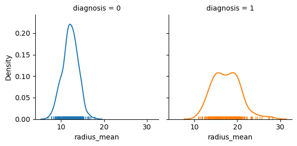

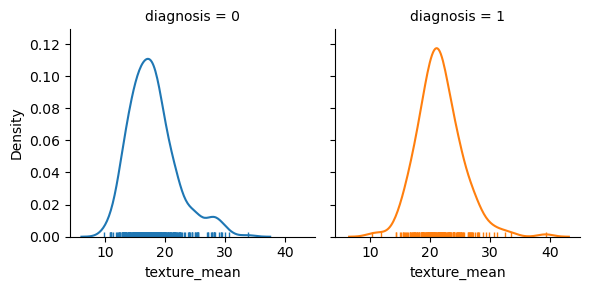

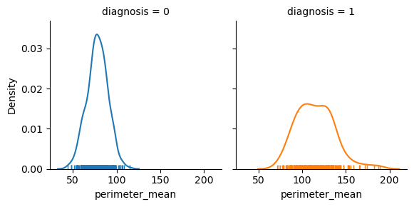

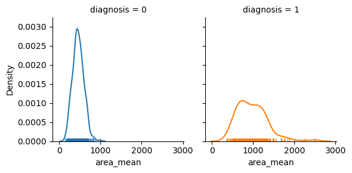

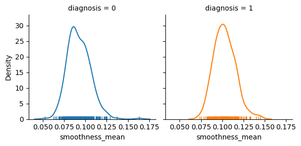

```python
g = sns.FacetGrid (df,col = 'diagnosis', hue = 'diagnosis')
g.map (sns.distplot, "radius_mean", hist = False, rug = True)

g = sns.FacetGrid (df,col = 'diagnosis', hue = 'diagnosis')
g.map (sns.distplot, 'texture_mean', hist = False, rug = True)

g = sns.FacetGrid (df,col = 'diagnosis', hue = 'diagnosis')
g.map (sns.distplot, 'perimeter_mean', hist = False, rug = True)

g = sns.FacetGrid (df,col = 'diagnosis', hue = 'diagnosis')
g.map (sns.distplot, "area_mean", hist = False, rug = True)

g = sns.FacetGrid (df,col = 'diagnosis', hue = 'diagnosis')
g.map (sns.distplot, "smoothness_mean", hist = False, rug = True)
plt.show()
```

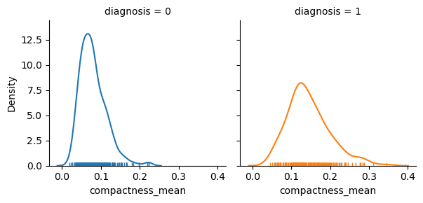

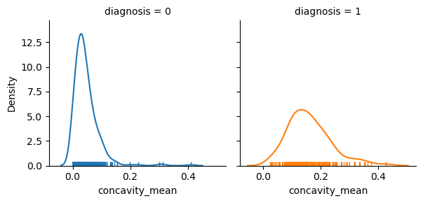

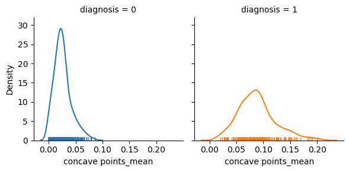

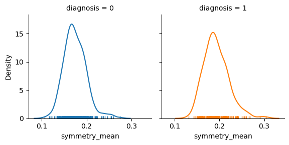

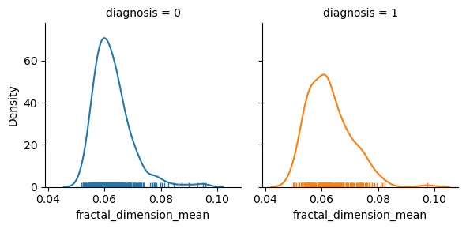

```python
g = sns.FacetGrid (df,col = 'diagnosis', hue = 'diagnosis')
g.map (sns.distplot, "compactness_mean", hist = False, rug = True)

g = sns.FacetGrid (df,col = 'diagnosis', hue = 'diagnosis')
g.map (sns.distplot, "concavity_mean", hist = False, rug = True)

g = sns.FacetGrid (df,col = 'diagnosis', hue = 'diagnosis')
g.map (sns.distplot, "concave points_mean", hist = False, rug = True)

g = sns.FacetGrid (df,col = 'diagnosis', hue = 'diagnosis')
g.map (sns.distplot, "symmetry_mean", hist = False, rug = True)

g = sns.FacetGrid (df,col = 'diagnosis', hue = 'diagnosis')
g.map (sns.distplot, "fractal_dimension_mean", hist = False, rug = True)
plt.show()
```

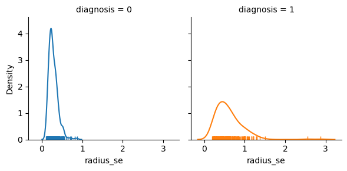

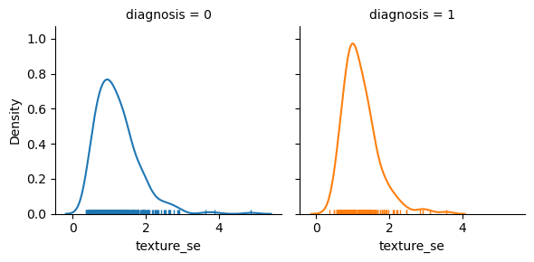

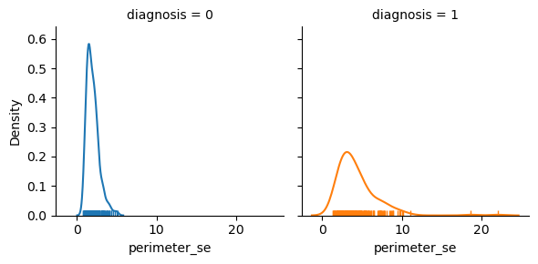

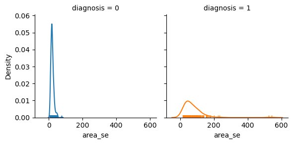

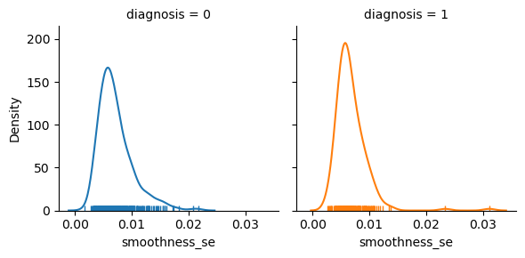

```python
g = sns.FacetGrid (df,col = 'diagnosis', hue = 'diagnosis')
g.map (sns.distplot, "radius_se", hist = False, rug = True)

g = sns.FacetGrid (df,col = 'diagnosis', hue = 'diagnosis')
g.map (sns.distplot, 'texture_se', hist = False, rug = True)

g = sns.FacetGrid (df,col = 'diagnosis', hue = 'diagnosis')
g.map (sns.distplot, 'perimeter_se', hist = False, rug = True)

g = sns.FacetGrid (df,col = 'diagnosis', hue = 'diagnosis')
g.map (sns.distplot, "area_se", hist = False, rug = True)

g = sns.FacetGrid (df,col = 'diagnosis', hue = 'diagnosis')
g.map (sns.distplot, "smoothness_se", hist = False, rug = True)
plt.show()
```

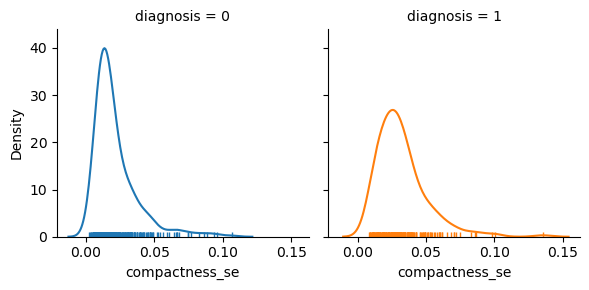

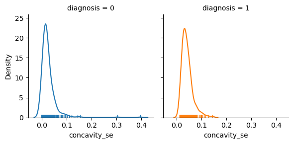

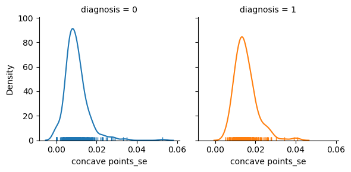

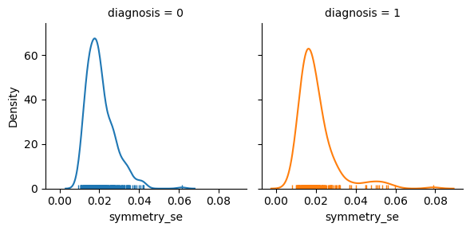

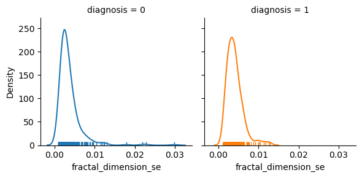

```python
g = sns.FacetGrid (df,col = 'diagnosis', hue = 'diagnosis')
g.map (sns.distplot, "compactness_se", hist = False, rug = True)

g = sns.FacetGrid (df,col = 'diagnosis', hue = 'diagnosis')
g.map (sns.distplot, "concavity_se", hist = False, rug = True)

g = sns.FacetGrid (df,col = 'diagnosis', hue = 'diagnosis')
g.map (sns.distplot, "concave points_se", hist = False, rug = True)

g = sns.FacetGrid (df,col = 'diagnosis', hue = 'diagnosis')
g.map (sns.distplot, "symmetry_se", hist = False, rug = True)

g = sns.FacetGrid (df,col = 'diagnosis', hue = 'diagnosis')
g.map (sns.distplot, "fractal_dimension_se", hist = False, rug = True)
plt.show()
```

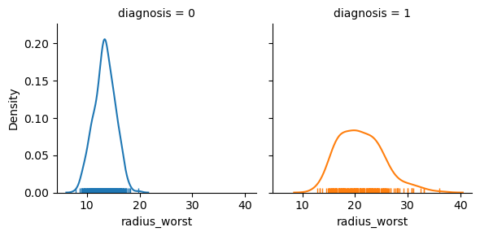

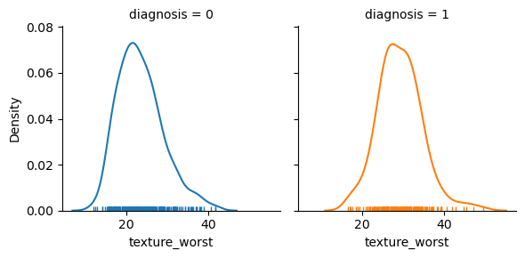

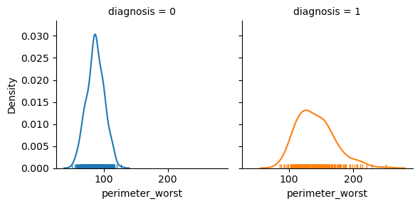

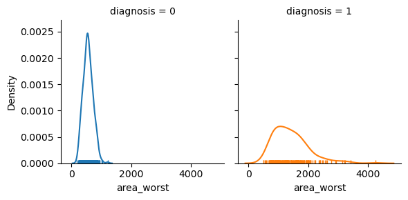

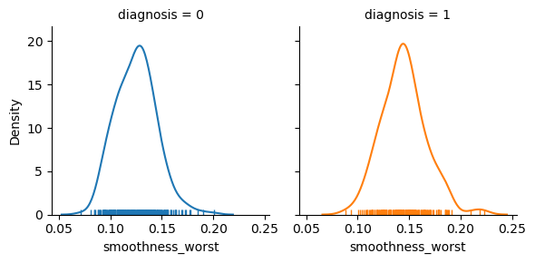

```python
g = sns.FacetGrid (df,col = 'diagnosis', hue = 'diagnosis')
g.map (sns.distplot, "radius_worst", hist = False, rug = True)

g = sns.FacetGrid (df,col = 'diagnosis', hue = 'diagnosis')
g.map (sns.distplot, 'texture_worst', hist = False, rug = True)

g = sns.FacetGrid (df,col = 'diagnosis', hue = 'diagnosis')
g.map (sns.distplot, 'perimeter_worst', hist = False, rug = True)

g = sns.FacetGrid (df,col = 'diagnosis', hue = 'diagnosis')
g.map (sns.distplot, "area_worst", hist = False, rug = True)

g = sns.FacetGrid (df,col = 'diagnosis', hue = 'diagnosis')
g.map (sns.distplot, "smoothness_worst", hist = False, rug = True)
plt.show()
```